# AIRBNB Listings in Singapore in 2019

## Mount google drive

```python
from google.colab import drive
drive.mount('/gdrive')
%cd /gdrive
```

```
/gdrive
```

```python
import numpy as np
import pandas as pd
import matplotlib.pyplot as plt
import matplotlib.image as mpimg
%matplotlib inline
import seaborn as sns
```

# Main Question: Which location is the most favorable for an Airbnb in Singapore?

## Read Dataset

```python
df = pd.read_csv("/gdrive/MyDrive/QAC155 final project/listings_2019.csv")
df.head()
```

|  | id | name | host_id | host_name | neighbourhood_group | neighbourhood | latitude | longitude | room_type | price | minimum_nights | number_of_reviews | last_review | reviews_per_month | calculated_host_listings_count | availability_365 |
| --- | --- | --- | --- | --- | --- | --- | --- | --- | --- | --- | --- | --- | --- | --- | --- | --- |
| 0 | 49091 | COZICOMFORT LONG TERM STAY ROOM 2 | 266763 | Francesca | North Region | Woodlands | 1.44255 | 103.79580 | Private room | 83 | 180 | 1 | 2013-10-21 | 0.01 | 2 | 365 |
| 1 | 50646 | Pleasant Room along Bukit Timah | 227796 | Sujatha | Central Region | Bukit Timah | 1.33235 | 103.78521 | Private room | 81 | 90 | 18 | 2014-12-26 | 0.28 | 1 | 365 |
| 2 | 56334 | COZICOMFORT | 266763 | Francesca | North Region | Woodlands | 1.44246 | 103.79667 | Private room | 69 | 6 | 20 | 2015-10-01 | 0.20 | 2 | 365 |
| 3 | 71609 | Ensuite Room (Room 1 & 2) near EXPO | 367042 | Belinda | East Region | Tampines | 1.34541 | 103.95712 | Private room | 206 | 1 | 14 | 2019-08-11 | 0.15 | 9 | 353 |
| 4 | 71896 | B&B Room 1 near Airport & EXPO | 367042 | Belinda | East Region | Tampines | 1.34567 | 103.95963 | Private room | 94 | 1 | 22 | 2019-07-28 | 0.22 | 9 | 355 |

```python
df.shape
```

```
(7907, 16)
```

```python
df.dtypes
```

```
id                                  int64
name                               object
host_id                             int64
host_name                          object
neighbourhood_group                object
neighbourhood                      object
latitude                          float64
longitude                         float64
room_type                          object
price                               int64
minimum_nights                      int64
number_of_reviews                   int64
last_review                        object
reviews_per_month                 float64
calculated_host_listings_count      int64
availability_365                    int64
dtype: object
```

## Cleaning the Data

```python
df.isnull().sum()
```

```
id                                   0
name                                 2
host_id                              0
host_name                            0
neighbourhood_group                  0
neighbourhood                        0
latitude                             0
longitude                            0
room_type                            0
price                                0
minimum_nights                       0
number_of_reviews                    0
last_review                       2758
reviews_per_month                 2758
calculated_host_listings_count       0
availability_365                     0
dtype: int64
```

```python
df.drop(['id','host_name','last_review'], axis=1, inplace=True)
df.head()
```

|  | name | host_id | neighbourhood_group | neighbourhood | latitude | longitude | room_type | price | minimum_nights | number_of_reviews | reviews_per_month | calculated_host_listings_count | availability_365 |
| --- | --- | --- | --- | --- | --- | --- | --- | --- | --- | --- | --- | --- | --- |
| 0 | COZICOMFORT LONG TERM STAY ROOM 2 | 266763 | North Region | Woodlands | 1.44255 | 103.79580 | Private room | 83 | 180 | 1 | 0.01 | 2 | 365 |
| 1 | Pleasant Room along Bukit Timah | 227796 | Central Region | Bukit Timah | 1.33235 | 103.78521 | Private room | 81 | 90 | 18 | 0.28 | 1 | 365 |
| 2 | COZICOMFORT | 266763 | North Region | Woodlands | 1.44246 | 103.79667 | Private room | 69 | 6 | 20 | 0.20 | 2 | 365 |
| 3 | Ensuite Room (Room 1 & 2) near EXPO | 367042 | East Region | Tampines | 1.34541 | 103.95712 | Private room | 206 | 1 | 14 | 0.15 | 9 | 353 |
| 4 | B&B Room 1 near Airport & EXPO | 367042 | East Region | Tampines | 1.34567 | 103.95963 | Private room | 94 | 1 | 22 | 0.22 | 9 | 355 |

```python
df['reviews_per_month'] = df['reviews_per_month'].fillna(0)
df.isnull().sum()
```

```
name                              2
host_id                           0
neighbourhood_group               0
neighbourhood                     0
latitude                          0
longitude                         0
room_type                         0
price                             0
minimum_nights                    0
number_of_reviews                 0
reviews_per_month                 0
calculated_host_listings_count    0
availability_365                  0
dtype: int64
```

```python
df[df.name.isnull()]
```

|  | name | host_id | neighbourhood_group | neighbourhood | latitude | longitude | room_type | price | minimum_nights | number_of_reviews | reviews_per_month | calculated_host_listings_count | availability_365 |
| --- | --- | --- | --- | --- | --- | --- | --- | --- | --- | --- | --- | --- | --- |
| 1024 | NaN | 41240585 | Central Region | Bukit Merah | 1.29108 | 103.83077 | Private room | 69 | 2 | 4 | 0.09 | 1 | 0 |
| 1331 | NaN | 61163169 | Central Region | Bishan | 1.35221 | 103.85148 | Private room | 650 | 1 | 0 | 0.00 | 1 | 0 |

```python
df.at[1024,'name'] = 'Airbnb1'
df.at[1331,'name']= 'Airbnb2'
```

```python
df[df.name.isnull()]
```

|  | name | host_id | neighbourhood_group | neighbourhood | latitude | longitude | room_type | price | minimum_nights | number_of_reviews | reviews_per_month | calculated_host_listings_count | availability_365 |
| --- | --- | --- | --- | --- | --- | --- | --- | --- | --- | --- | --- | --- | --- |

```python
df.neighbourhood_group.unique()
```

```
array(['North Region', 'Central Region', 'East Region', 'West Region',
       'North-East Region'], dtype=object)
```

```python
df.neighbourhood.unique()
```

```
array(['Woodlands', 'Bukit Timah', 'Tampines', 'Bedok', 'Bukit Merah',
       'Newton', 'Geylang', 'River Valley', 'Jurong West', 'Rochor',
       'Queenstown', 'Serangoon', 'Marine Parade', 'Pasir Ris',
       'Toa Payoh', 'Outram', 'Punggol', 'Tanglin', 'Hougang', 'Kallang',
       'Novena', 'Downtown Core', 'Bukit Panjang', 'Singapore River',
       'Orchard', 'Ang Mo Kio', 'Bukit Batok', 'Museum', 'Sembawang',
       'Choa Chu Kang', 'Central Water Catchment', 'Sengkang', 'Clementi',
       'Jurong East', 'Bishan', 'Yishun', 'Mandai', 'Southern Islands',
       'Sungei Kadut', 'Western Water Catchment', 'Tuas', 'Marina South',
       'Lim Chu Kang'], dtype=object)
```

```python
df.room_type.unique()
```

```
array(['Private room', 'Entire home/apt', 'Shared room'], dtype=object)
```

## Which airbnb hosts have the most listings?

```python
count_listing = df.host_id.value_counts(sort=True).reset_index()
count_listing.columns = ['host_id','count']
count_listing.head(10)
```

|  | host_id | count |
| --- | --- | --- |
| 0 | 66406177 | 274 |
| 1 | 8492007 | 203 |
| 2 | 209913841 | 157 |
| 3 | 29420853 | 141 |
| 4 | 31464513 | 114 |
| 5 | 219550151 | 113 |
| 6 | 2413412 | 112 |
| 7 | 108773366 | 109 |
| 8 | 23722617 | 84 |
| 9 | 8948251 | 83 |

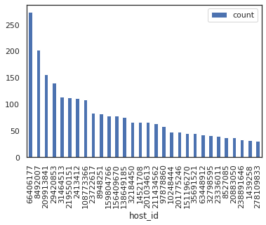

```python
count_listing.head(30).plot.bar(x='host_id',y='count')
```

## On average, how many listings does each host have?

```python
count_listing['count'].mean()
```

```
2.923105360443623
```

## Count of listings by room type

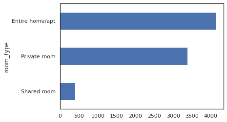

```python
df.groupby('room_type').size().sort_values(ascending=True).plot.barh()
```

## Which geographic region has the most number of listings? What is the proportion of room types in each?

```python
df_neighborhood_listing = df.groupby(["neighbourhood_group",'room_type']).size().unstack(level='room_type')
#df_neighborhood_listing = df_neighborhood_listing.reset_index()
df_neighborhood_listing['total']=df_neighborhood_listing.sum(axis=1)
df_neighborhood_listing_top = df_neighborhood_listing.sort_values(by='total', ascending=False).fillna(0).head(10)
df_neighborhood_listing_top
```

| room_type neighbourhood_group | Entire home/apt | Private room | Shared room | total |
| --- | --- | --- | --- | --- |
| Central Region | 3738 | 2223 | 348 | 6309 |
| West Region | 146 | 378 | 16 | 540 |
| East Region | 131 | 366 | 11 | 508 |
| North-East Region | 64 | 272 | 10 | 346 |
| North Region | 53 | 142 | 9 | 204 |

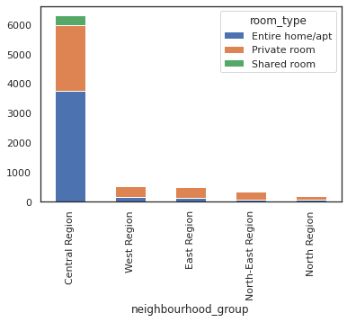

```python
sub1 = df_neighborhood_listing_top.drop('total', axis=1)
sub1.plot.bar(stacked=True)
```

## Top 10 neighborhoods and proportion of room type

```python
df_neighborhoods_listing = df.groupby(["neighbourhood_group","neighbourhood",'room_type']).size().unstack(level='room_type')
df_neighborhoods_listing['total']=df_neighborhoods_listing.sum(axis=1)
df_neighborhoods_listing_top = df_neighborhoods_listing.sort_values(by='total', ascending=False).fillna(0).head(10)
df_neighborhoods_listing_top
```

| neighbourhood_group | room_type neighbourhood | Entire home/apt | Private room | Shared room | total |
| --- | --- | --- | --- | --- | --- |
| Central Region | Kallang | 521.0 | 438.0 | 84.0 | 1043.0 |
|  | Geylang | 715.0 | 271.0 | 8.0 | 994.0 |
|  | Novena | 428.0 | 109.0 | 0.0 | 537.0 |
|  | Rochor | 279.0 | 189.0 | 68.0 | 536.0 |
|  | Outram | 166.0 | 244.0 | 67.0 | 477.0 |
|  | Bukit Merah | 296.0 | 163.0 | 11.0 | 470.0 |
|  | Downtown Core | 314.0 | 105.0 | 9.0 | 428.0 |
| East Region | Bedok | 106.0 | 261.0 | 6.0 | 373.0 |
| Central Region | River Valley | 222.0 | 137.0 | 3.0 | 362.0 |
|  | Queenstown | 129.0 | 119.0 | 18.0 | 266.0 |

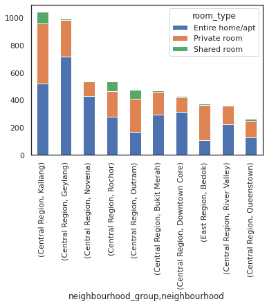

```python
sub2 = df_neighborhoods_listing_top.drop('total', axis=1)
sub2.plot.bar(stacked=True)
```

## Price distribution of listings

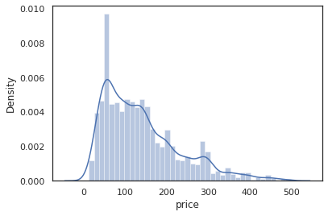

```python
price_dist = df[df['price']<500] #to remove outliers
sns.distplot(price_dist['price'])
```

```python
df['price'].describe()
```

```
count     7907.000000
mean       169.332996
std        340.187599
min          0.000000
25%         65.000000
50%        124.000000
75%        199.000000
max      10000.000000
Name: price, dtype: float64
```

## Average price of each room type

```python
df.groupby('room_type')['price'].mean()
```

```
room_type
Entire home/apt    226.998306
Private room       110.938480
Shared room         65.675127
Name: price, dtype: float64
```

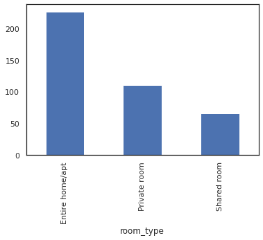

```python
df.groupby('room_type')['price'].mean().plot.bar()
```

Since the price of private rooms is around half the price of an entire home, if the house has >2 rooms it might make more sense to rent out each room separately to collect more rent.

## Are most of the top host listings private rooms?

```python
top_hosts = count_listing.head(10)
top_hosts
```

|  | host_id | count |
| --- | --- | --- |
| 0 | 66406177 | 274 |
| 1 | 8492007 | 203 |
| 2 | 209913841 | 157 |
| 3 | 29420853 | 141 |
| 4 | 31464513 | 114 |
| 5 | 219550151 | 113 |
| 6 | 2413412 | 112 |
| 7 | 108773366 | 109 |
| 8 | 23722617 | 84 |
| 9 | 8948251 | 83 |

```python
df_top_hosts = df[df['host_id'].isin(top_hosts['host_id'])]
df_top_hosts.head()
```

|  | name | host_id | neighbourhood_group | neighbourhood | latitude | longitude | room_type | price | minimum_nights | number_of_reviews | reviews_per_month | calculated_host_listings_count | availability_365 |
| --- | --- | --- | --- | --- | --- | --- | --- | --- | --- | --- | --- | --- | --- |
| 35 | Chinatown@doorstep: *Queenbed Room 891 | 2413412 | Central Region | Outram | 1.28315 | 103.84213 | Private room | 44 | 90 | 2 | 0.02 | 112 | 365 |
| 47 | Chinatown Doorstep: *Ensuite 1+1+ WOW city view! | 2413412 | Central Region | Outram | 1.28291 | 103.84284 | Private room | 65 | 90 | 3 | 0.04 | 112 | 0 |
| 50 | Aljunied *RoomC > MRT 3min > CBD 15 mins | 2413412 | Central Region | Geylang | 1.31525 | 103.88176 | Private room | 35 | 18 | 6 | 0.15 | 112 | 359 |
| 53 | Chinatown your doorstep: Ensuite M203 | 2413412 | Central Region | Outram | 1.28491 | 103.84209 | Private room | 60 | 28 | 6 | 0.16 | 112 | 333 |
| 61 | Heritage apartment: Master Rm4* +bathroom (3mth+) | 2413412 | Central Region | Kallang | 1.31135 | 103.85946 | Private room | 49 | 18 | 2 | 0.05 | 112 | 360 |

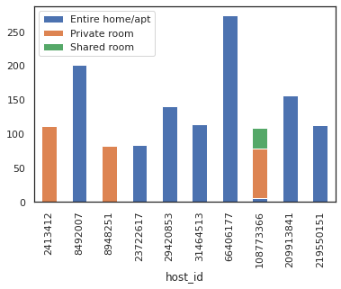

```python
plot1 = df_top_hosts.groupby(['host_id','room_type'])['room_type'].count().unstack()
plot1.reset_index()
plot1.columns=[	'Entire home/apt',	'Private room','Shared room']
plot1.plot.bar(stacked=True)
```

## What is the most expensive listing?

```python
df.sort_values(by='price', ascending=False).head()
```

|  | name | host_id | neighbourhood_group | neighbourhood | latitude | longitude | room_type | price | minimum_nights | number_of_reviews | reviews_per_month | calculated_host_listings_count | availability_365 |
| --- | --- | --- | --- | --- | --- | --- | --- | --- | --- | --- | --- | --- | --- |
| 2978 | YOUR entire PRIVATE LUXURY PENTHOUSE condo unit | 122991242 | West Region | Tuas | 1.31909 | 103.64656 | Entire home/apt | 10000 | 2 | 5 | 0.21 | 1 | 89 |
| 2392 | Comfortable & Quiet Master Bedroom | 68223771 | West Region | Bukit Panjang | 1.34775 | 103.77181 | Private room | 10000 | 1 | 1 | 0.04 | 1 | 0 |
| 5823 | Testing | 20307016 | Central Region | Kallang | 1.29610 | 103.86613 | Private room | 10000 | 1 | 0 | 0.00 | 1 | 0 |
| 2100 | The Club Residences - Contemporary Manor | 84411185 | Central Region | Southern Islands | 1.25284 | 103.82225 | Entire home/apt | 8900 | 2 | 0 | 0.00 | 6 | 361 |
| 3485 | The Club Residences - Contemporary Manor (A) | 84411185 | Central Region | Southern Islands | 1.25054 | 103.82551 | Entire home/apt | 8900 | 2 | 0 | 0.00 | 6 | 0 |

## What is the least expensive listing?

```python
df.sort_values(by='price', ascending=True).head()
```

|  | name | host_id | neighbourhood_group | neighbourhood | latitude | longitude | room_type | price | minimum_nights | number_of_reviews | reviews_per_month | calculated_host_listings_count | availability_365 |
| --- | --- | --- | --- | --- | --- | --- | --- | --- | --- | --- | --- | --- | --- |
| 3168 | 1 BR @ Little India & Farrer Park MRT | 114674497 | Central Region | Rochor | 1.30954 | 103.85271 | Entire home/apt | 0 | 3 | 9 | 0.51 | 6 | 351 |
| 7249 | Senja cozy | 75175440 | West Region | Bukit Panjang | 1.38400 | 103.76309 | Entire home/apt | 14 | 1 | 1 | 0.45 | 2 | 0 |
| 2557 | Master Bedroom at The Clearwater Condo | 21900076 | East Region | Bedok | 1.33698 | 103.93293 | Shared room | 14 | 1 | 0 | 0.00 | 2 | 0 |
| 2567 | Small room for you | 108408404 | Central Region | Marine Parade | 1.30823 | 103.89461 | Private room | 14 | 2 | 1 | 0.04 | 1 | 0 |
| 7674 | Central 1BR Apt in Foodie Haven Hipster Paradise | 29799617 | Central Region | Geylang | 1.31455 | 103.88323 | Entire home/apt | 14 | 3 | 4 | 4.00 | 1 | 34 |

## Which neighborhoods have the highest average listing price?

```python
df_neighborhood_price = df[["neighbourhood",'price']]
#.agg(['mean', 'count']).sort_values(by='mean',ascending=False)
df_neighborhood_price_top = df_neighborhood_price.groupby('neighbourhood')['price'].agg(['mean','min','max','count']).sort_values(by='mean',ascending=False)
df_neighborhood_price_top[:10]
```

| neighbourhood | mean | min | max | count |
| --- | --- | --- | --- | --- |
| Tuas | 10000.000000 | 10000 | 10000 | 1 |
| Southern Islands | 1893.764706 | 200 | 8900 | 17 |
| Marina South | 419.000000 | 419 | 419 | 1 |
| Bukit Panjang | 365.352941 | 14 | 10000 | 34 |
| Orchard | 291.029412 | 36 | 900 | 136 |
| Museum | 236.317460 | 50 | 790 | 63 |
| Bukit Batok | 206.169231 | 25 | 6944 | 65 |
| Downtown Core | 205.394860 | 19 | 1456 | 428 |
| Tanglin | 201.276190 | 31 | 2604 | 210 |
| Singapore River | 189.937143 | 19 | 1481 | 175 |

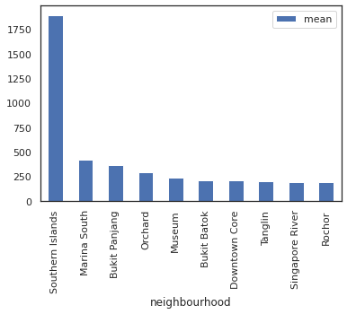

```python
df_neighborhood_price_top[1:11].plot.bar(y='mean')
```

```python
sns.set(rc={'figure.figsize':(16,10)})
sns.set_style('white')
```

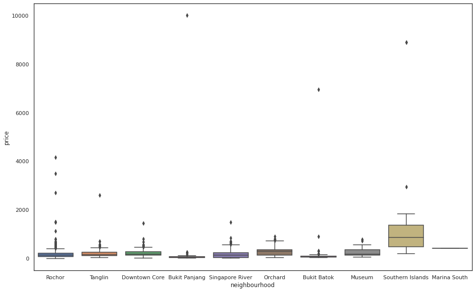

```python
sub3 = df.loc[df['neighbourhood'].isin(df_neighborhood_price_top[1:11].index)]
sns.boxplot(data=sub3, x='neighbourhood',y='price')
```

### Remove extreme values

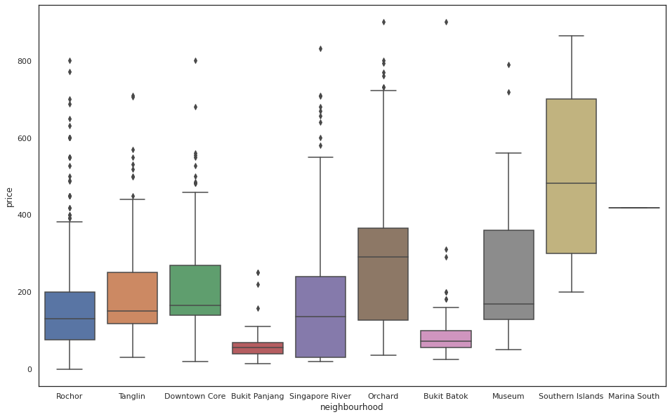

```python
sub4 = sub3[sub3['price']<1000]
sns.boxplot(data=sub4, x='neighbourhood',y='price')
```

## Price visualization with geospatial data

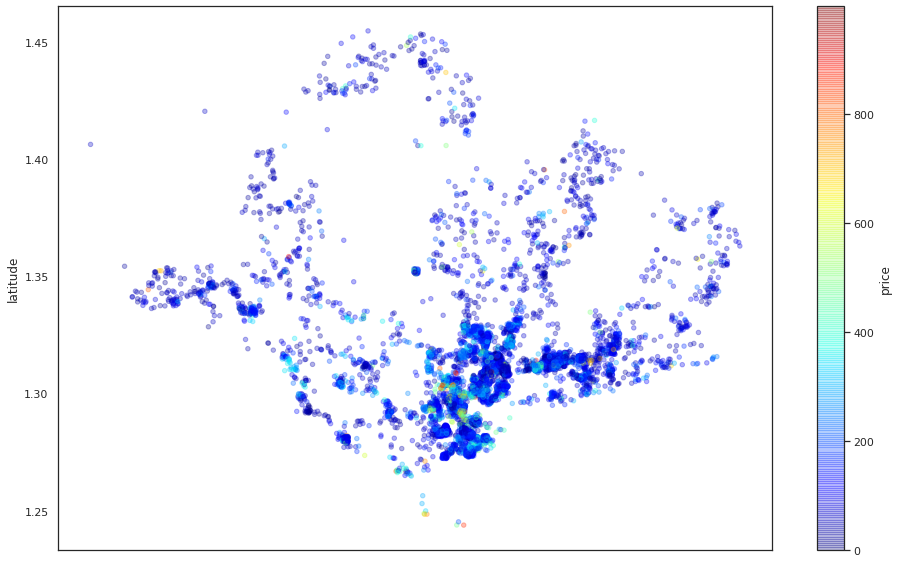

```python
sub5 = df[df['price']<1000]
price_geo = sub5.plot(kind='scatter', x='longitude', y='latitude', c='price',
                  cmap=plt.get_cmap('jet'), colorbar=True, alpha=0.3, figsize=(16,10))
```

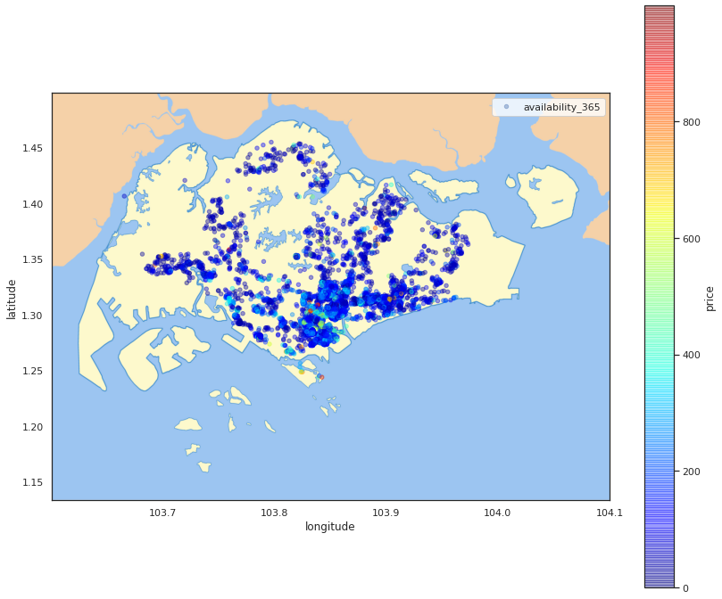

```python
import urllib
#initializing the figure size
plt.figure(figsize=(14,12))
#loading the png NYC image found on Google and saving to my local folder along with the project
i=urllib.request.urlopen('https://upload.wikimedia.org/wikipedia/commons/c/ca/Singapore-OutlineMap-20050606.png')
sg_img=plt.imread(i)
#scaling the image based on the latitude and longitude max and mins for proper output
plt.imshow(sg_img,zorder=0,extent=[103.6006, 104.1,  1.13387,1.49859])
ax=plt.gca()
#using scatterplot again
sub5.plot(kind='scatter', x='longitude', y='latitude', label='availability_365', c='price', ax=ax,
           cmap=plt.get_cmap('jet'), colorbar=True, alpha=0.4, zorder=1)
```

## Average no. of reviews for each room type

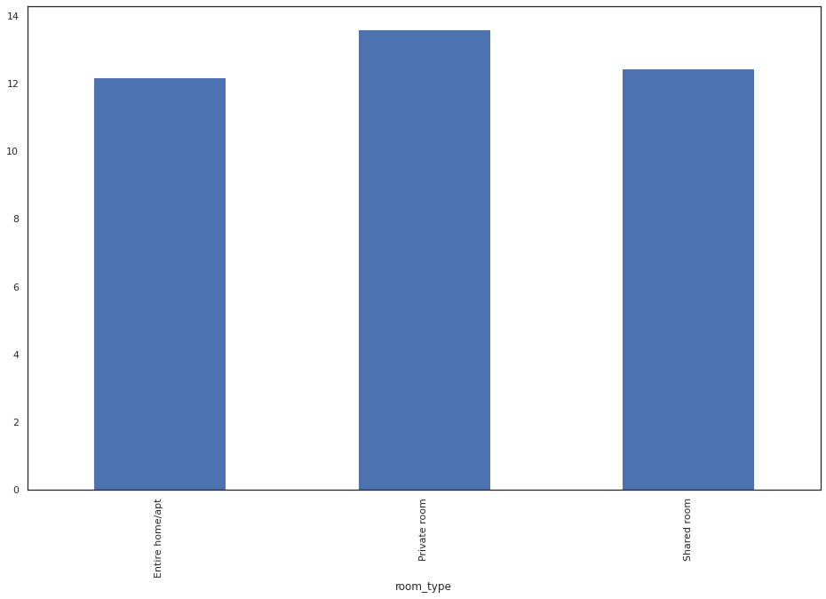

```python
df.groupby('room_type')['number_of_reviews'].mean().plot.bar()
```

## Average no. of reviews per month for each room type

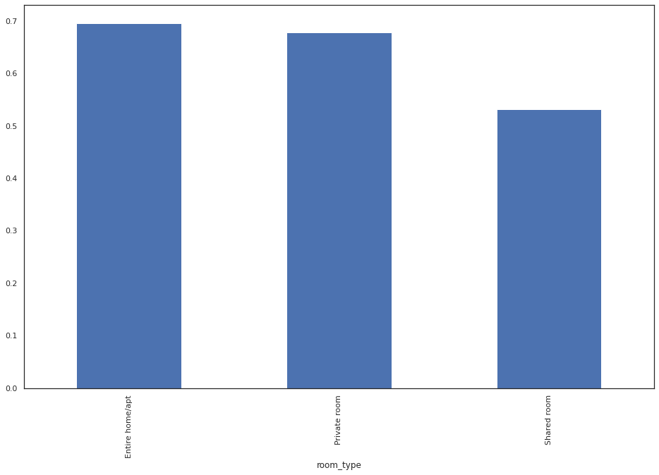

```python
df.groupby('room_type')['reviews_per_month'].mean().plot.bar()
```

## Most reviewed listing

Total number of reviews may not nessarily mean that the listing is the most popular. It may just be that the listing has been on Airbnb for a long time. The reviews per month of each listing may therefore be a more accurate measure of a listing's popularity.

```python
df.sort_values(by='number_of_reviews',ascending=False).head()
```

|  | name | host_id | neighbourhood_group | neighbourhood | latitude | longitude | room_type | price | minimum_nights | number_of_reviews | reviews_per_month | calculated_host_listings_count | availability_365 |
| --- | --- | --- | --- | --- | --- | --- | --- | --- | --- | --- | --- | --- | --- |
| 132 | Luxuriously Spacious Studio Apt. | 7642747 | East Region | Bedok | 1.32122 | 103.91492 | Entire home/apt | 139 | 2 | 323 | 4.72 | 1 | 239 |
| 140 | Heritage Shophouse Right in Epicentre of Sights | 1346787 | Central Region | Outram | 1.28448 | 103.84360 | Private room | 69 | 1 | 307 | 5.44 | 3 | 315 |
| 470 | The Lily Room | 30080617 | East Region | Tampines | 1.34463 | 103.96107 | Private room | 60 | 2 | 296 | 5.56 | 7 | 0 |
| 1237 | Spacious room near Woodleigh MRT | 44793532 | Central Region | Toa Payoh | 1.33431 | 103.87554 | Private room | 49 | 1 | 296 | 6.96 | 2 | 288 |
| 722 | Clean cosy room, 7 mins to Sentosa | 34333799 | Central Region | Bukit Merah | 1.27718 | 103.82167 | Private room | 72 | 3 | 291 | 6.05 | 1 | 186 |

## Listing with most number of reviews per month

```python
df.sort_values(by='reviews_per_month',ascending=False).head()
```

|  | name | host_id | neighbourhood_group | neighbourhood | latitude | longitude | room_type | price | minimum_nights | number_of_reviews | reviews_per_month | calculated_host_listings_count | availability_365 |
| --- | --- | --- | --- | --- | --- | --- | --- | --- | --- | --- | --- | --- | --- |
| 7447 | Private Single Cabin,5 min walk to Chinatown MRT | 223971227 | Central Region | Outram | 1.28076 | 103.84563 | Private room | 69 | 1 | 13 | 13.00 | 14 | 1 |
| 3196 | Close to Changi Airport/Biz Park/Expo(S) | 156290352 | East Region | Pasir Ris | 1.36287 | 103.97342 | Private room | 85 | 1 | 276 | 12.60 | 2 | 287 |
| 7446 | Private Single Cabin ,5 min.walk to Chinatown MRT | 223971227 | Central Region | Outram | 1.28116 | 103.84417 | Private room | 69 | 1 | 12 | 12.00 | 14 | 2 |
| 7139 | Resort-style Living in Serene Neighbourhood | 6359940 | North-East Region | Hougang | 1.35279 | 103.87746 | Private room | 75 | 1 | 25 | 11.03 | 1 | 141 |
| 7000 | SPACIOUS CLEAN ROOM WITH 2 SINGLE BEDS NEAR BUGIS | 263831162 | Central Region | Downtown Core | 1.29680 | 103.85578 | Private room | 67 | 2 | 24 | 8.37 | 5 | 58 |

## Neighborhoods with the highest average monthly reviews

```python
df_neighborhood_review = df.groupby('neighbourhood')['reviews_per_month'].agg(['mean','max','min','count']).sort_values(by='mean',ascending=False)
df_neighborhood_review['mean_price'] = df_neighborhood_price_top['mean']
df_neighborhood_review['price_review'] = df_neighborhood_review['mean'] * df_neighborhood_review['mean_price']
df_neighborhood_review.sort_values(by='price_review', ascending=False)
```

| neighbourhood | mean | max | min | count | mean_price | price_review |
| --- | --- | --- | --- | --- | --- | --- |
| Tuas | 0.210000 | 0.21 | 0.21 | 1 | 10000.000000 | 2100.000000 |
| Southern Islands | 0.377647 | 5.13 | 0.00 | 17 | 1893.764706 | 715.174671 |
| Museum | 1.474603 | 6.95 | 0.00 | 63 | 236.317460 | 348.474477 |
| Orchard | 0.765294 | 5.27 | 0.00 | 136 | 291.029412 | 222.723097 |
| Sungei Kadut | 1.790000 | 4.28 | 0.00 | 5 | 111.200000 | 199.048000 |
| Rochor | 0.941194 | 6.67 | 0.00 | 536 | 188.792910 | 177.690760 |
| Downtown Core | 0.832383 | 8.37 | 0.00 | 428 | 205.394860 | 170.967226 |
| Newton | 0.830075 | 5.63 | 0.00 | 134 | 188.746269 | 156.673489 |
| Marine Parade | 1.072865 | 6.00 | 0.00 | 171 | 145.818713 | 156.443866 |
| Tanglin | 0.753381 | 8.07 | 0.00 | 210 | 201.276190 | 151.637648 |
| Bukit Panjang | 0.409118 | 3.65 | 0.00 | 34 | 365.352941 | 149.472336 |
| River Valley | 0.850276 | 5.83 | 0.00 | 362 | 164.977901 | 140.276789 |
| Geylang | 0.824889 | 7.32 | 0.00 | 994 | 161.598592 | 133.300955 |
| Tampines | 1.090000 | 6.71 | 0.00 | 64 | 100.390625 | 109.425781 |
| Bedok | 0.670751 | 6.35 | 0.00 | 373 | 158.630027 | 106.401197 |
| Outram | 0.713061 | 13.00 | 0.00 | 477 | 145.937107 | 104.062030 |
| Kallang | 0.613087 | 7.60 | 0.00 | 1043 | 166.162991 | 101.872411 |
| Yishun | 0.836792 | 8.00 | 0.00 | 53 | 121.584906 | 101.741331 |
| Singapore River | 0.491143 | 4.69 | 0.00 | 175 | 189.937143 | 93.286271 |
| Marina South | 0.220000 | 0.22 | 0.22 | 1 | 419.000000 | 92.180000 |
| Central Water Catchment | 0.477647 | 4.45 | 0.00 | 34 | 184.852941 | 88.294464 |
| Novena | 0.496164 | 6.12 | 0.00 | 537 | 177.441341 | 88.039983 |
| Toa Payoh | 0.571188 | 7.81 | 0.00 | 101 | 153.237624 | 87.527510 |
| Bukit Merah | 0.570979 | 7.23 | 0.00 | 470 | 151.442553 | 86.470476 |
| Bishan | 0.501754 | 3.96 | 0.00 | 57 | 170.508772 | 85.553524 |
| Pasir Ris | 0.799718 | 12.60 | 0.00 | 71 | 95.746479 | 76.570212 |
| Hougang | 0.554220 | 11.03 | 0.00 | 109 | 124.321101 | 68.901263 |
| Bukit Timah | 0.440382 | 3.23 | 0.00 | 131 | 153.969466 | 67.805332 |
| Sengkang | 0.883582 | 5.79 | 0.00 | 67 | 74.850746 | 66.136779 |
| Jurong East | 0.340169 | 4.28 | 0.00 | 118 | 184.720339 | 62.836224 |
| Serangoon | 0.682609 | 5.19 | 0.00 | 69 | 91.173913 | 62.236106 |
| Bukit Batok | 0.289846 | 3.00 | 0.00 | 65 | 206.169231 | 59.757359 |
| Clementi | 0.334118 | 5.10 | 0.00 | 102 | 170.705882 | 57.035848 |
| Punggol | 0.643023 | 4.66 | 0.00 | 43 | 85.744186 | 55.135506 |
| Choa Chu Kang | 0.559841 | 2.58 | 0.00 | 63 | 93.317460 | 52.242965 |
| Woodlands | 0.561194 | 5.11 | 0.00 | 67 | 81.492537 | 45.733125 |
| Queenstown | 0.310150 | 4.08 | 0.00 | 266 | 140.364662 | 43.534153 |
| Mandai | 0.586667 | 0.97 | 0.27 | 3 | 56.666667 | 33.244444 |
| Ang Mo Kio | 0.312414 | 2.52 | 0.00 | 58 | 103.448276 | 32.318668 |
| Jurong West | 0.348954 | 2.37 | 0.00 | 153 | 91.045752 | 31.770802 |
| Sembawang | 0.168537 | 1.73 | 0.00 | 41 | 88.268293 | 14.876437 |
| Western Water Catchment | 0.295000 | 1.06 | 0.03 | 4 | 46.250000 | 13.643750 |
| Lim Chu Kang | 0.000000 | 0.00 | 0.00 | 1 | 65.000000 | 0.000000 |

By multiplying average monthly reviews and average listing price we can see which neighborhoods generate the most income.

Tuas is an outlier since it only has one listing at a price of `$10000`. Southern islands has a very high average listing price of`$1893`, which would not be ideal for the average tourist.

Hence the top 3 neighborhoods are **Museum, Orchard and Rochor**.*

**Sungei Kadut is excluded since it has only 5 listings.*

## Which price range has the highest average number of reviews per month?

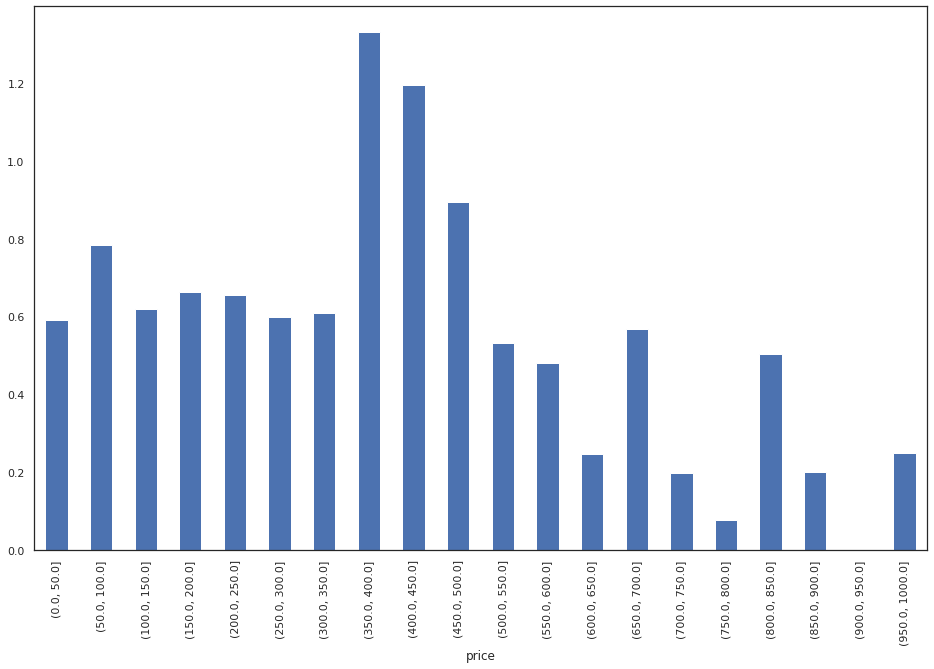

```python
df.groupby(pd.cut(df.price, np.linspace(0,1000,21))).reviews_per_month.mean().plot.bar()
```

It seems that the `$350-$400` and `$400-$450` range has the highest average number of reviews per month.

# Which amenities correlate with reviews per month?

This is done by calculating the distance between the listing and the closest amenity for each amenity type (e.g. Supermarkets, train stations, malls, hawkers)

### Import geopandas

```python
!pip install geopandas
!pip install rtree
!pip install descartes
import geopandas as gpd
import rtree
```

## Read amenities' shape file

Supermarkets, Train Stations, National Parks, Hawkers (food court), Tourist Attractions

```python
map = gpd.read_file("/gdrive/MyDrive/QAC155 final project/map/MP14_REGION_WEB_PL.shp")
map = map.to_crs(crs="EPSG:3414")
supermarket = gpd.read_file("/gdrive/MyDrive/QAC155 final project/supermarkets/SUPERMARKETS.shp")
supermarket = supermarket.to_crs(crs="EPSG:3414")
train = gpd.read_file("/gdrive/MyDrive/QAC155 final project/mrt/G_MP14_RAIL_STN_PL.shp")
train = train.to_crs(crs="EPSG:3414")
park = gpd.read_file("/gdrive/MyDrive/QAC155 final project/nationalparks/NATIONALPARKS.shp")
park = park.to_crs(crs="EPSG:3414")
hawker = gpd.read_file("/gdrive/MyDrive/QAC155 final project/hawker/HAWKERCENTRE.shp")
hawker = hawker.to_crs(crs="EPSG:3414")
tourism = gpd.read_file("/gdrive/MyDrive/QAC155 final project/touristattractions/TOURISM.shp")
tourism = tourism.to_crs(crs="EPSG:3414")
```

```python
park = park[park['HYPERLINK'].astype(str)!='None'] # removing non-parks. Dataset included playgrounds which I would like removed
```

## Create geodataframe from airbnb listing dataframe

```python
geo_df = gpd.GeoDataFrame(df, geometry=gpd.points_from_xy(df['longitude'], df['latitude'], crs="EPSG:4326"))
geo_df = geo_df.to_crs(crs="EPSG:3414")
geo_df.head()
```

|  | name | host_id | neighbourhood_group | neighbourhood | latitude | longitude | room_type | price | minimum_nights | number_of_reviews | reviews_per_month | calculated_host_listings_count | availability_365 | geometry |
| --- | --- | --- | --- | --- | --- | --- | --- | --- | --- | --- | --- | --- | --- | --- |
| 0 | COZICOMFORT LONG TERM STAY ROOM 2 | 266763 | North Region | Woodlands | 1.44255 | 103.79580 | Private room | 83 | 180 | 1 | 0.01 | 2 | 365 | POINT (23824.765 47135.402) |
| 1 | Pleasant Room along Bukit Timah | 227796 | Central Region | Bukit Timah | 1.33235 | 103.78521 | Private room | 81 | 90 | 18 | 0.28 | 1 | 365 | POINT (22646.015 34950.063) |
| 2 | COZICOMFORT | 266763 | North Region | Woodlands | 1.44246 | 103.79667 | Private room | 69 | 6 | 20 | 0.20 | 2 | 365 | POINT (23921.583 47125.448) |
| 3 | Ensuite Room (Room 1 & 2) near EXPO | 367042 | East Region | Tampines | 1.34541 | 103.95712 | Private room | 206 | 1 | 14 | 0.15 | 9 | 353 | POINT (41777.748 36394.468) |
| 4 | B&B Room 1 near Airport & EXPO | 367042 | East Region | Tampines | 1.34567 | 103.95963 | Private room | 94 | 1 | 22 | 0.22 | 9 | 355 | POINT (42057.083 36423.232) |

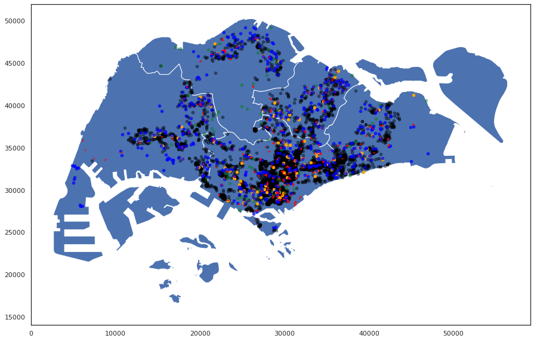

```python
ax = map.plot(figsize=(15, 15))
geo_df.plot(ax=ax,  color='black', alpha=0.4, zorder=1,markersize=20)
hawker.plot(ax=ax, alpha=1, color="orange", zorder=2, markersize=20)
supermarket.plot(ax=ax, alpha=0.7, color="blue", zorder=3, markersize=20)
train.plot(ax=ax, alpha=1, color="red", edgecolor="red", zorder=4)
park.plot(ax=ax, alpha=0.4, color="green", zorder=5, markersize=20)
#tourism.plot(ax=ax, alpha=0.7, color="yellow")
```

## Create new columns for minimum distance to amenity

```python
def min_distance(point1, point2):
    return point2.distance(point1).min()

geo_df['min_dist_to_supermarket'] = geo_df.geometry.apply(min_distance, args=(supermarket.geometry,))
geo_df['min_dist_to_train'] = geo_df.geometry.apply(min_distance, args=(train.geometry,))
geo_df['min_dist_to_park'] = geo_df.geometry.apply(min_distance, args=(park.geometry,))
geo_df['min_dist_to_hawker'] = geo_df.geometry.apply(min_distance, args=(hawker.geometry,))
geo_df['min_dist_to_tourism'] = geo_df.geometry.apply(min_distance, args=(tourism.geometry,))
```

## Convert distance to kilometers

```python
geo_df['min_dist_to_supermarket'] = geo_df['min_dist_to_supermarket']/1000
geo_df['min_dist_to_train'] = geo_df['min_dist_to_train']/1000
geo_df['min_dist_to_park'] = geo_df['min_dist_to_park']/1000
geo_df['min_dist_to_hawker'] = geo_df['min_dist_to_hawker']/1000
geo_df['min_dist_to_tourism'] = geo_df['min_dist_to_tourism']/1000

geo_df.head()
```

|  | name | host_id | neighbourhood_group | neighbourhood | latitude | longitude | room_type | price | minimum_nights | number_of_reviews | reviews_per_month | calculated_host_listings_count | availability_365 | geometry | min_dist_to_supermarket | min_dist_to_train | min_dist_to_park | min_dist_to_hawker | min_dist_to_tourism |
| --- | --- | --- | --- | --- | --- | --- | --- | --- | --- | --- | --- | --- | --- | --- | --- | --- | --- | --- | --- |
| 0 | COZICOMFORT LONG TERM STAY ROOM 2 | 266763 | North Region | Woodlands | 1.44255 | 103.79580 | Private room | 83 | 180 | 1 | 0.01 | 2 | 365 | POINT (23824.765 47135.402) | 0.428163 | 0.528395 | 1.539629 | 0.616979 | 4.235475 |
| 1 | Pleasant Room along Bukit Timah | 227796 | Central Region | Bukit Timah | 1.33235 | 103.78521 | Private room | 81 | 90 | 18 | 0.28 | 1 | 365 | POINT (22646.015 34950.063) | 0.506642 | 0.332696 | 2.224064 | 1.286578 | 2.863406 |
| 2 | COZICOMFORT | 266763 | North Region | Woodlands | 1.44246 | 103.79667 | Private room | 69 | 6 | 20 | 0.20 | 2 | 365 | POINT (23921.583 47125.448) | 0.386152 | 0.439093 | 1.636947 | 0.528076 | 4.233732 |
| 3 | Ensuite Room (Room 1 & 2) near EXPO | 367042 | East Region | Tampines | 1.34541 | 103.95712 | Private room | 206 | 1 | 14 | 0.15 | 9 | 353 | POINT (41777.748 36394.468) | 0.545093 | 0.459830 | 2.079642 | 1.390848 | 2.641994 |
| 4 | B&B Room 1 near Airport & EXPO | 367042 | East Region | Tampines | 1.34567 | 103.95963 | Private room | 94 | 1 | 22 | 0.22 | 9 | 355 | POINT (42057.083 36423.232) | 0.804864 | 0.367275 | 2.258636 | 1.669956 | 2.429198 |

## Compute linear regression of reviews per month and amenities

```python
import statsmodels.api as sm
```

```python
y = geo_df['reviews_per_month']
X = geo_df[['min_dist_to_supermarket','min_dist_to_train','min_dist_to_park','min_dist_to_hawker','min_dist_to_tourism']]
X = sm.add_constant(X)
results = sm.OLS(y, X).fit()
results.summary()
```

OLS Regression Results

| Dep. Variable: | reviews_per_month | R-squared: | 0.005 |
| --- | --- | --- | --- |
| Model: | OLS | Adj. R-squared: | 0.004 |
| Method: | Least Squares | F-statistic: | 8.040 |
| Date: | Sun, 23 May 2021 | Prob (F-statistic): | 1.42e-07 |
| Time: | 18:05:01 | Log-Likelihood: | -12309. |
| No. Observations: | 7907 | AIC: | 2.463e+04 |
| Df Residuals: | 7901 | BIC: | 2.467e+04 |
| Df Model: | 5 |  |  |
| Covariance Type: | nonrobust |  |  |

|  | coef | std err | t | P>\|t\| | [0.025 | 0.975] |
| --- | --- | --- | --- | --- | --- | --- |
| const | 0.6845 | 0.031 | 22.163 | 0.000 | 0.624 | 0.745 |
| min_dist_to_supermarket | -0.0790 | 0.058 | -1.366 | 0.172 | -0.192 | 0.034 |
| min_dist_to_train | -0.1380 | 0.038 | -3.588 | 0.000 | -0.213 | -0.063 |
| min_dist_to_park | 0.0883 | 0.019 | 4.636 | 0.000 | 0.051 | 0.126 |
| min_dist_to_hawker | 0.0278 | 0.035 | 0.797 | 0.425 | -0.041 | 0.096 |
| min_dist_to_tourism | -0.0407 | 0.013 | -3.133 | 0.002 | -0.066 | -0.015 |

| Omnibus: | 4861.263 | Durbin-Watson: | 1.726 |
| --- | --- | --- | --- |
| Prob(Omnibus): | 0.000 | Jarque-Bera (JB): | 53328.362 |
| Skew: | 2.831 | Prob(JB): | 0.00 |
| Kurtosis: | 14.394 | Cond. No. | 10.8 |

Warnings:  
[1] Standard Errors assume that the covariance matrix of the errors is correctly specified.

From this statistic, we can see train stations, parks and tourist attractions have p values < 0.05 and thus there is a significant correlation for these amenities i.e. When the distance to the closest train station increases by 1km, reviews per month decreases by 0.1380 points, when the distance to the closest park increases by 1km, reviews per month increases by 0.0883 points and when the distance to the closest tourist attraction increases by 1km, reviews per month decreases by 0.0407 points.

**Not surprisingly, distance to train stations is an important factor in determining an Airbnb's popularity. The closer the train station, the higher the number of reviews per month.**

## Average distance to nearest train station

```python
geo_df['min_dist_to_train'].agg(['mean','median'])
```

```
mean      0.426179
median    0.334441
Name: min_dist_to_train, dtype: float64
```

The average distance from an airbnb listing to the nearest train station is about **426 meters**. Just a 5 minute walk.

# Do number of amenities within walking distance affect reviews per month?

This is done by creating a 1km buffer and counting the number of amenities that fall within it.

### Create buffer of 1000m

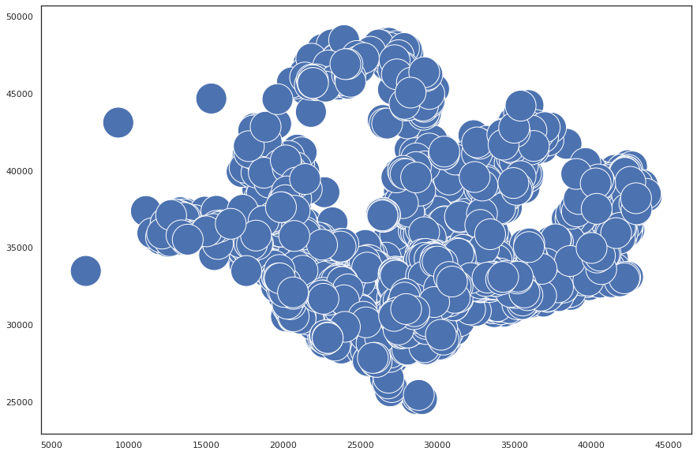

```python
buffers = geo_df.buffer(distance=1000, resolution=50)
buffers.plot()
```

```python
buffers_df = gpd.GeoDataFrame(geo_df, geometry=buffers)

buffers_df.head()
```

|  | name | host_id | neighbourhood_group | neighbourhood | latitude | longitude | room_type | price | minimum_nights | number_of_reviews | reviews_per_month | calculated_host_listings_count | availability_365 | geometry | min_dist_to_supermarket | min_dist_to_train | min_dist_to_park | min_dist_to_hawker | min_dist_to_tourism |
| --- | --- | --- | --- | --- | --- | --- | --- | --- | --- | --- | --- | --- | --- | --- | --- | --- | --- | --- | --- |
| 0 | COZICOMFORT LONG TERM STAY ROOM 2 | 266763 | North Region | Woodlands | 1.44255 | 103.79580 | Private room | 83 | 180 | 1 | 0.01 | 2 | 365 | POLYGON ((24824.765 47135.402, 24824.272 47103... | 0.428163 | 0.528395 | 1.539629 | 0.616979 | 4.235475 |
| 1 | Pleasant Room along Bukit Timah | 227796 | Central Region | Bukit Timah | 1.33235 | 103.78521 | Private room | 81 | 90 | 18 | 0.28 | 1 | 365 | POLYGON ((23646.015 34950.063, 23645.522 34918... | 0.506642 | 0.332696 | 2.224064 | 1.286578 | 2.863406 |
| 2 | COZICOMFORT | 266763 | North Region | Woodlands | 1.44246 | 103.79667 | Private room | 69 | 6 | 20 | 0.20 | 2 | 365 | POLYGON ((24921.583 47125.448, 24921.089 47094... | 0.386152 | 0.439093 | 1.636947 | 0.528076 | 4.233732 |
| 3 | Ensuite Room (Room 1 & 2) near EXPO | 367042 | East Region | Tampines | 1.34541 | 103.95712 | Private room | 206 | 1 | 14 | 0.15 | 9 | 353 | POLYGON ((42777.748 36394.468, 42777.255 36363... | 0.545093 | 0.459830 | 2.079642 | 1.390848 | 2.641994 |
| 4 | B&B Room 1 near Airport & EXPO | 367042 | East Region | Tampines | 1.34567 | 103.95963 | Private room | 94 | 1 | 22 | 0.22 | 9 | 355 | POLYGON ((43057.083 36423.232, 43056.589 36391... | 0.804864 | 0.367275 | 2.258636 | 1.669956 | 2.429198 |

### Spatial join of buffer and amenities

```python
walking_dist_train = gpd.sjoin(buffers_df, train) #Spatial join Points to polygons
walking_dist_supermarket = gpd.sjoin(buffers_df, supermarket) #Spatial join Points to polygons
walking_dist_park = gpd.sjoin(buffers_df, park) #Spatial join Points to polygons
walking_dist_hawker = gpd.sjoin(buffers_df, hawker) #Spatial join Points to polygons
walking_dist_tourism = gpd.sjoin(buffers_df, tourism) #Spatial join Points to polygons
```

## Pivot to obtain total no. of amenities within 1000 meters of listing

### Total no. of train stations

```python
dfpivot_train = pd.pivot_table(walking_dist_train,index='name',columns='TYPE',aggfunc={'TYPE':len})
dfpivot_train.columns = dfpivot_train.columns.droplevel()

dfpivot_train['train_stations'] = dfpivot_train.sum(axis=1) # Sum different types of train stations

dfpivot_train = dfpivot_train.drop(columns=['CCL', 'LRT','MRT']) # remove train stations and keep only total no.

dfpivot_train.head()
```

| TYPE name | train_stations |
| --- | --- |
| !! CozyRoom@City Center,Little India,FarrerParkMRT | 5.0 |
| !!!2BR ART Apartment near shopping mall Katong ON5 | 3.0 |
| !!!2BR Amazing Apartment Phenthouse @ Katong ON7 | 3.0 |
| !!!2BR Spacious ART Katong near shopping mall ON6 | 3.0 |
| !!!Amazing 2 Bedroom Penthouse View @ Katong ON8 | 3.0 |

### Total no. of parks

```python
dfpivot_park = pd.pivot_table(walking_dist_park,index='name',columns='FMEL_UPD_D',aggfunc={'FMEL_UPD_D':len})
dfpivot_park.columns = dfpivot_park.columns.droplevel()
dfpivot_park['parks'] = dfpivot_park.sum(axis=1)
dfpivot_park = dfpivot_park.drop(columns=['2020-02-18',	'2020-09-30',	'2021-01-22'])
dfpivot_park.head()
```

| FMEL_UPD_D name | parks |
| --- | --- |
| #1 Huge Loft like apt w/DJ studio & amazing views | 2.0 |
| #2 Huge Loft like apt w/DJ studio & amazing views | 3.0 |
| #Luxurious Seaside Camping (4pax) | 1.0 |
| ( 3 )Rooms at Same Condo Unit just opposite of Mrt | 1.0 |
| (*3 MTHS STAY ONWARD) 高级套房 high quality suite | 1.0 |

### Total no. of supermarkets

```python
dfpivot_supermarket = pd.pivot_table(walking_dist_supermarket,index='name',columns='FMEL_UPD_D',aggfunc={'FMEL_UPD_D':len})
dfpivot_supermarket.columns = dfpivot_supermarket.columns.droplevel()
dfpivot_supermarket['supermarkets'] = dfpivot_supermarket.sum(axis=1)
dfpivot_supermarket = dfpivot_supermarket.drop(columns=['2017-11-29','2018-02-22','2018-07-11','2018-10-03','2019-01-24'])
dfpivot_supermarket.head()
```

| FMEL_UPD_D name | supermarkets |
| --- | --- |
| !! CozyRoom@City Center,Little India,FarrerParkMRT | 6.0 |
| !!!2BR ART Apartment near shopping mall Katong ON5 | 12.0 |
| !!!2BR Amazing Apartment Phenthouse @ Katong ON7 | 12.0 |
| !!!2BR Spacious ART Katong near shopping mall ON6 | 11.0 |
| !!!Amazing 2 Bedroom Penthouse View @ Katong ON8 | 12.0 |

### Total no. of tourist attractions

```python
dfpivot_tourism = pd.pivot_table(walking_dist_tourism,index='name',columns='FMEL_UPD_D',aggfunc={'FMEL_UPD_D':len})
dfpivot_tourism.columns = dfpivot_tourism.columns.droplevel()
dfpivot_tourism['tourism'] = dfpivot_tourism.sum(axis=1)
dfpivot_tourism = dfpivot_tourism.drop(columns=['2017-01-09'])
dfpivot_tourism.head()
```

| FMEL_UPD_D name | tourism |
| --- | --- |
| !! CozyRoom@City Center,Little India,FarrerParkMRT | 2 |
| !!!2BR ART Apartment near shopping mall Katong ON5 | 1 |
| !!!2BR Amazing Apartment Phenthouse @ Katong ON7 | 1 |
| !!!2BR Spacious ART Katong near shopping mall ON6 | 1 |
| !!!Amazing 2 Bedroom Penthouse View @ Katong ON8 | 1 |

### Total no. of hawkers

```python
dfpivot_hawker = pd.pivot_table(walking_dist_hawker,index='name',columns='FMEL_UPD_D',aggfunc={'FMEL_UPD_D':len})
dfpivot_hawker.columns = dfpivot_hawker.columns.droplevel()
dfpivot_hawker['hawkers'] = dfpivot_hawker.sum(axis=1)
dfpivot_hawker = dfpivot_hawker.drop(columns=['2020-08-05',	'2020-09-24',	'2020-10-30','2020-12-28','2021-01-08','2021-01-20','2021-02-02'
,'2021-02-05','2021-02-22','2021-03-16'])
dfpivot_hawker.head()
```

| FMEL_UPD_D name | hawkers |
| --- | --- |
| !! CozyRoom@City Center,Little India,FarrerParkMRT | 3.0 |
| !!!2BR ART Apartment near shopping mall Katong ON5 | 4.0 |
| !!!2BR Amazing Apartment Phenthouse @ Katong ON7 | 3.0 |
| !!!2BR Spacious ART Katong near shopping mall ON6 | 4.0 |
| !!!Amazing 2 Bedroom Penthouse View @ Katong ON8 | 3.0 |

## Merge the amenity counts with the original airbnb listing dataset

```python
geo_df_new = geo_df.merge(dfpivot_train, how = 'left', on='name')
geo_df_new = geo_df_new.merge(dfpivot_supermarket, how = 'left', on='name')
geo_df_new = geo_df_new.merge(dfpivot_tourism, how = 'left', on='name')
geo_df_new = geo_df_new.merge(dfpivot_hawker, how = 'left', on='name')
geo_df_new = geo_df_new.merge(dfpivot_park, how = 'left', on='name')
```

```python
geo_df_new = geo_df_new.fillna(0)
geo_df_new['amenity_total'] = geo_df_new['train_stations'] + geo_df_new['supermarkets'] + geo_df_new['tourism'] + geo_df_new['hawkers']
+ geo_df_new['parks']
geo_df_new.head()
```

|  | name | host_id | neighbourhood_group | neighbourhood | latitude | longitude | room_type | price | minimum_nights | number_of_reviews | reviews_per_month | calculated_host_listings_count | availability_365 | geometry | min_dist_to_supermarket | min_dist_to_train | min_dist_to_park | min_dist_to_hawker | min_dist_to_tourism | train_stations | supermarkets | tourism | hawkers | parks | amenity_total |
| --- | --- | --- | --- | --- | --- | --- | --- | --- | --- | --- | --- | --- | --- | --- | --- | --- | --- | --- | --- | --- | --- | --- | --- | --- | --- |
| 0 | COZICOMFORT LONG TERM STAY ROOM 2 | 266763 | North Region | Woodlands | 1.44255 | 103.79580 | Private room | 83 | 180 | 1 | 0.01 | 2 | 365 | POLYGON ((24824.765 47135.402, 24824.272 47103... | 0.428163 | 0.528395 | 1.539629 | 0.616979 | 4.235475 | 1.0 | 10.0 | 0.0 | 1.0 | 0.0 | 12.0 |
| 1 | Pleasant Room along Bukit Timah | 227796 | Central Region | Bukit Timah | 1.33235 | 103.78521 | Private room | 81 | 90 | 18 | 0.28 | 1 | 365 | POLYGON ((23646.015 34950.063, 23645.522 34918... | 0.506642 | 0.332696 | 2.224064 | 1.286578 | 2.863406 | 1.0 | 2.0 | 0.0 | 0.0 | 0.0 | 3.0 |
| 2 | COZICOMFORT | 266763 | North Region | Woodlands | 1.44246 | 103.79667 | Private room | 69 | 6 | 20 | 0.20 | 2 | 365 | POLYGON ((24921.583 47125.448, 24921.089 47094... | 0.386152 | 0.439093 | 1.636947 | 0.528076 | 4.233732 | 1.0 | 10.0 | 0.0 | 1.0 | 0.0 | 12.0 |
| 3 | Ensuite Room (Room 1 & 2) near EXPO | 367042 | East Region | Tampines | 1.34541 | 103.95712 | Private room | 206 | 1 | 14 | 0.15 | 9 | 353 | POLYGON ((42777.748 36394.468, 42777.255 36363... | 0.545093 | 0.459830 | 2.079642 | 1.390848 | 2.641994 | 2.0 | 3.0 | 0.0 | 0.0 | 0.0 | 5.0 |
| 4 | B&B Room 1 near Airport & EXPO | 367042 | East Region | Tampines | 1.34567 | 103.95963 | Private room | 94 | 1 | 22 | 0.22 | 9 | 355 | POLYGON ((43057.083 36423.232, 43056.589 36391... | 0.804864 | 0.367275 | 2.258636 | 1.669956 | 2.429198 | 2.0 | 4.0 | 0.0 | 0.0 | 0.0 | 6.0 |

## Compute linear regression of reviews per month and amenity count

```python
y = geo_df_new['reviews_per_month']
X = geo_df_new[['train_stations','supermarkets','tourism','hawkers','parks']]
X = sm.add_constant(X)
results = sm.OLS(y, X).fit()
results.summary()
```

OLS Regression Results

| Dep. Variable: | reviews_per_month | R-squared: | 0.007 |
| --- | --- | --- | --- |
| Model: | OLS | Adj. R-squared: | 0.006 |
| Method: | Least Squares | F-statistic: | 10.96 |
| Date: | Sun, 23 May 2021 | Prob (F-statistic): | 1.57e-10 |
| Time: | 18:05:16 | Log-Likelihood: | -12302. |
| No. Observations: | 7907 | AIC: | 2.462e+04 |
| Df Residuals: | 7901 | BIC: | 2.466e+04 |
| Df Model: | 5 |  |  |
| Covariance Type: | nonrobust |  |  |

|  | coef | std err | t | P>\|t\| | [0.025 | 0.975] |
| --- | --- | --- | --- | --- | --- | --- |
| const | 0.7133 | 0.018 | 39.501 | 0.000 | 0.678 | 0.749 |
| train_stations | 0.0086 | 0.004 | 2.028 | 0.043 | 0.000 | 0.017 |
| supermarkets | -0.0012 | 0.003 | -0.403 | 0.687 | -0.007 | 0.005 |
| tourism | 0.0076 | 0.002 | 3.158 | 0.002 | 0.003 | 0.012 |
| hawkers | -0.0269 | 0.006 | -4.596 | 0.000 | -0.038 | -0.015 |
| parks | -0.0187 | 0.008 | -2.442 | 0.015 | -0.034 | -0.004 |

| Omnibus: | 4834.940 | Durbin-Watson: | 1.727 |
| --- | --- | --- | --- |
| Prob(Omnibus): | 0.000 | Jarque-Bera (JB): | 52644.238 |
| Skew: | 2.813 | Prob(JB): | 0.00 |
| Kurtosis: | 14.320 | Cond. No. | 36.0 |

Warnings:  
[1] Standard Errors assume that the covariance matrix of the errors is correctly specified.

While the p-value for train stations and tourist attractions are < 0.05, the coefficient is negligible.

```python
y = geo_df_new['reviews_per_month']
X = geo_df_new[['amenity_total']]
X = sm.add_constant(X)
results = sm.OLS(y, X).fit()
results.summary()
```

OLS Regression Results

| Dep. Variable: | reviews_per_month | R-squared: | 0.000 |
| --- | --- | --- | --- |
| Model: | OLS | Adj. R-squared: | 0.000 |
| Method: | Least Squares | F-statistic: | 2.001 |
| Date: | Sun, 23 May 2021 | Prob (F-statistic): | 0.157 |
| Time: | 18:05:16 | Log-Likelihood: | -12328. |
| No. Observations: | 7907 | AIC: | 2.466e+04 |
| Df Residuals: | 7905 | BIC: | 2.467e+04 |
| Df Model: | 1 |  |  |
| Covariance Type: | nonrobust |  |  |

|  | coef | std err | t | P>\|t\| | [0.025 | 0.975] |
| --- | --- | --- | --- | --- | --- | --- |
| const | 0.6914 | 0.015 | 44.998 | 0.000 | 0.661 | 0.721 |
| amenity_total | -0.0004 | 0.000 | -1.415 | 0.157 | -0.001 | 0.000 |

| Omnibus: | 4868.045 | Durbin-Watson: | 1.728 |
| --- | --- | --- | --- |
| Prob(Omnibus): | 0.000 | Jarque-Bera (JB): | 53404.975 |
| Skew: | 2.836 | Prob(JB): | 0.00 |
| Kurtosis: | 14.398 | Cond. No. | 58.7 |

Warnings:  
[1] Standard Errors assume that the covariance matrix of the errors is correctly specified.

Total amenity count does not have any correlation with review per month either.

**Therfore, the number of amenities in walking distance (1000 meter) is not a significant factor for determining an Airbnb's popularity.** This may be because Singapore is a small country and it has a good public transport system; the distance to a single train station is more important than the number of amenities in walking distance because amenities are easily accesible bya short train ride.

# In conclusion

The most favourable place for an airbnb listing in Singapore is in the neighborhood of **Museum, Orchard or Rochor**. It should also be close to a train station. It should be priced around `$350-$400` per night.